# The Office

Adele Ossareh[^1]

30/3/2022

First we need to load the required libraries

```r
library(dplyr) # Data manipulation
library(ggplot2) # For plotting
library(rvest) # For web scraping
library(stringr) # Helping us with regex
library(ggthemes) # The economist theme
```

# Description

*The Office* is an American mockumentary sitcom television series that depicts the everyday work lives of office employees in the *Scranton, Pennsylvania* branch of the fictional *Dunder Mifflin* Paper Company. It aired on **NBC** from March 24, 2005, to May 16, 2013, spanning a total of nine seasons. Based on the 2001–2003 **BBC** series of the same name created by *Ricky Gervais* and *Stephen Merchant*, it was adapted for American television by *Greg Daniels*, a veteran writer for *Saturday Night Live*, *King of the Hill*, and *The Simpsons*.

# A shot or logo from the show

Below you can find a picture from the show

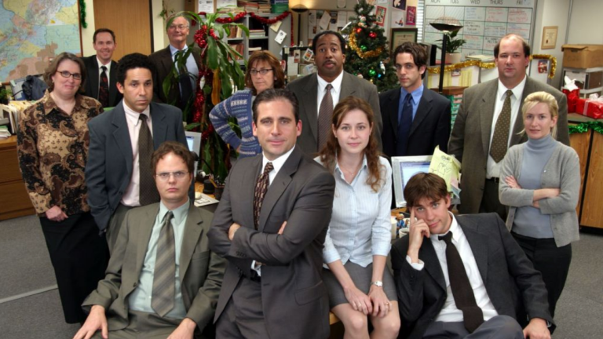

# Statistics summary

Based on the scraped data from *The Office* page in Wikipedia, we can see that the maximum number of the viewers was **11.2** millions and the minimum was **4.28** millions. Also the average number of the viewers from the calculated summary is **8.52** millions which shows that how successful the series was.

# A graph for the number of viewers by season

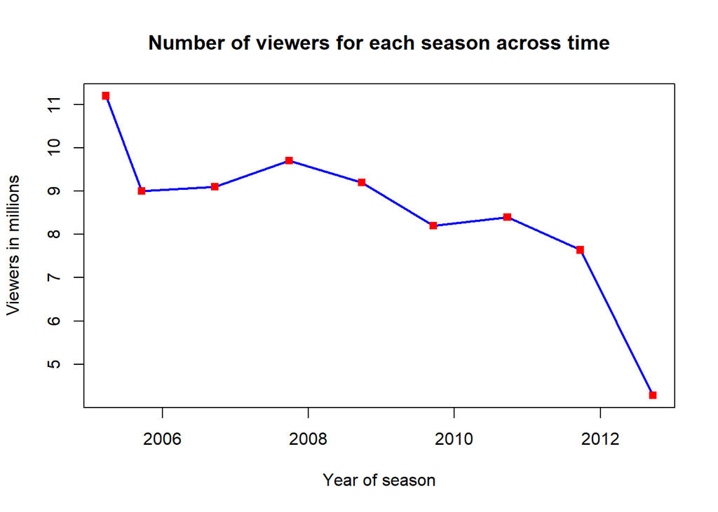

# Plot of Season-to-season changes

We can present the difference in viewership for season to season change. This time we will use ggplot package for a nicer look! :)

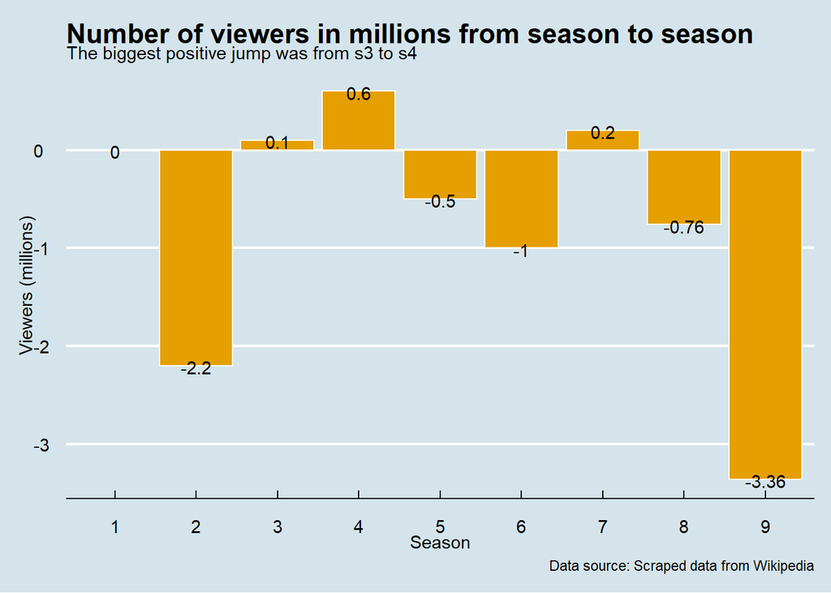

# A short description

We can see that in **The Office** the number of episodes changed through these **9** seasons. The season with the maximum number of episodes was **5** with **28** episodes. Another thing to mention here is that the highest drop in number of viewers in the show which happened in season **9** and the average change of viewers in the series was **-0.77** millions. Needless to say that the best season based the number of viewers was season **1**, which is not a surprised as usually the first seasons are more popular and when the shows moving on, the number usually drops.

[^1]: University of Warsaw, a.ossareh@student.uw.edu.pl